# Sandipan_Roy_Capstone_Final_Project_Notebook

**Business Context:**

AlphaCom, a leading telecommunications provider, has recently experienced a concerning rise in customer churn despite offering competitive services and a wide product portfolio. This increase is directly impacting revenue and undermining brand reputation in an intensely competitive market. Traditional retention strategies have proven inadequate because customer churn is influenced by a complex mix of factors, including service usage, billing preferences, contract types, and demographics. Without clear insights into these patterns, the company is left reacting to churn instead of preventing it.

**Business Significance:**

Industry research consistently shows that the cost of acquiring a new customer is **5–6** times higher than retaining an existing one. Therefore, even a marginal improvement in customer retention can lead to substantial cost savings. In addition, the probability of successfully selling new products or services to existing customers is significantly higher (**60–70%**) compared to new customers (**5–20%**). This makes customer retention not only a defensive strategy, but also a strong revenue growth opportunity.

From a financial perspective, increasing customer retention by just 5% can boost profits by **25% to 95%**, depending on the industry. At a macro level, U.S. companies are estimated to lose approximately **$136.8** billion annually due to avoidable customer churn, highlighting the scale of the problem. These benchmarks emphasize why understanding, predicting, and preventing churn is a high‑priority business objective.

Customer churn is not merely the loss of customers; it directly affects revenue, customer lifetime value, operational efficiency, and brand reputation. High churn rates often indicate underlying issues such as poor service quality, pricing dissatisfaction, or weak customer engagement. Hence, a data‑driven churn analysis enables organizations to move from reactive churn management to proactive retention strategies.

**Objective:**

As a data scientist at AlphaCom, you are tasked with developing a predictive model to identify customers at high risk of churn and uncover the key factors driving their decisions. Solving this problem will enable the company to proactively design targeted retention strategies, reduce churn-related losses, and improve customer lifetime value, ultimately safeguarding revenue and strengthening AlphaCom’s competitive position.

**Data Description:**

The data contains different attributes related to churn. The detailed data dictionary is given below:

- **Gender:** The customer’s gender (e.g., Male or Female). This demographic feature may correlate with customer behavior.
- **Age Range:** Indicates the customer’s age bracket (e.g., 18–25, 26–35, etc.), offering demographic insights that can impact churn analysis.
- **SeniorCitizen:** A binary indicator (if included) that identifies whether the customer is a senior citizen (commonly 1 for senior, 0 for non-senior). Senior status can influence service preferences and retention strategies.
- **Partner:** Indicates whether the customer has a partner. This factor can affect customer loyalty and service usage patterns.
- **Dependents:** Specifies whether the customer has dependents. This information can provide context on the customer’s household and influence their service needs.
- **Tenure:** The number of months the customer has been with the company. Longer tenure may indicate higher loyalty, while shorter tenure could be a churn risk indicator.
- **PhoneService:** Denotes whether the customer subscribes to telephone services. This binary feature (Yes/No) helps understand service adoption.
- **MultipleLines:** Indicates if the customer has multiple phone lines. This feature can provide insight into customer behavior and service complexity.
- **InternetService:** Describes the type of internet service the customer uses (e.g., DSL, Fiber optic, or None). The type of internet service can be a critical factor in churn analysis.
- **OnlineSecurity:** Shows whether the customer subscribes to online security services. This value (Yes/No) may influence customer satisfaction and retention.
- **OnlineBackup:** Indicates if the customer has an online backup service. Similar to online security, this can be a part of the overall service bundle affecting churn.
- **DeviceProtection:** Specifies whether the customer is enrolled in a device protection plan, providing an added layer of service value.
- **TechSupport:** Denotes if the customer subscribes to technical support services. Access to tech support can improve customer experience and reduce churn.
- **StreamingTV:** Indicates whether the customer subscribes to a streaming TV service. Media consumption patterns can be a differentiator in customer preferences.
- **StreamingMovies:** Specifies if the customer subscribes to a streaming movies service. This, combined with other services, can highlight trends in customer behavior.
- **Contract:** Describes the type of contract the customer holds (e.g., month-to-month, one-year, or two-year). Contract type is a strong indicator of churn risk—shorter contracts are often associated with higher churn.
- **PaperlessBilling:** Indicates whether the customer is enrolled in paperless billing. This operational feature can sometimes correlate with customer engagement levels.
- **PaymentMethod:** Details the payment method used by the customer (e.g., electronic check, mailed check, bank transfer, or credit card). Payment methods can affect both churn and overall customer satisfaction.
- **MonthlyCharges:** The monthly amount in USD charged to the customer. Higher charges might increase the likelihood of churn if customers perceive the cost as too high for the value provided.
- **TotalCharges:** The cumulative amount in $ USD charged over the customer’s tenure. This helps in understanding the long-term value of each customer and can be a predictor of churn.
- **Churn:** The target variable indicating whether the customer has left (typically denoted as “Yes” or “No”). This is the primary outcome you aim to predict with your machine learning model.

# Import Libraries

```python
# Installing the libraries with the specified version.
# uncomment and run the following line if Google Colab is being used
# !pip install scikit-learn==1.2.2 seaborn==0.13.1 matplotlib==3.7.1 numpy==1.25.2 pandas==1.5.3 imbalanced-learn==0.10.1 xgboost==2.0.3 -q --user
```

```python
# Installing the libraries with the specified version.
# uncomment and run the following lines if Jupyter Notebook is being used
# !pip install scikit-learn==1.2.2 seaborn==0.13.1 matplotlib==3.7.1 numpy==1.25.2 pandas==1.5.3 imbalanced-learn==0.10.1 xgboost==2.0.3 -q --user
# !pip install --upgrade -q threadpoolctl
```

```python
# Libraries to help with reading and manipulating data
import pandas as pd
import numpy as np

# Libaries to help with data visualization
import matplotlib.pyplot as plt
import seaborn as sns

# Removes the limit for the number of displayed columns
pd.set_option("display.max_columns", None)
# Sets the limit for the number of displayed rows
pd.set_option("display.max_rows", 200)

# To build model for prediction
import statsmodels.stats.api as sms
from statsmodels.stats.outliers_influence import variance_inflation_factor
import statsmodels.api as sm
from statsmodels.tools.tools import add_constant
import sklearn # Added sklearn import
from sklearn.linear_model import LogisticRegression

# To tune model, get different metric scores, and split data
from sklearn.metrics import (
    f1_score,
    accuracy_score,
    recall_score,
    precision_score,
    confusion_matrix,
    ConfusionMatrixDisplay,
    roc_auc_score,
    precision_recall_curve,
    roc_curve,
)
from sklearn.model_selection import train_test_split, StratifiedKFold, cross_val_score

# To be used for data scaling and one hot encoding
from sklearn.preprocessing import StandardScaler, MinMaxScaler, OneHotEncoder

# To oversample and undersample data
from imblearn.over_sampling import SMOTE
from imblearn.under_sampling import RandomUnderSampler

# To do hyperparameter tuning
from sklearn.model_selection import RandomizedSearchCV

# To impute missing values
from sklearn.impute import SimpleImputer

# To define maximum number of columns to be displayed in a dataframe
pd.set_option("display.max_columns", None)

# To supress scientific notations for a dataframe
pd.set_option("display.float_format", lambda x: "%.3f" % x)

# To help with model building
from sklearn.tree import DecisionTreeClassifier
from sklearn.ensemble import (
    AdaBoostClassifier,
    GradientBoostingClassifier,
    RandomForestClassifier,
    BaggingClassifier,
)
from xgboost import XGBClassifier

# To suppress scientific notations
pd.set_option("display.float_format", lambda x: "%.3f" % x)

# To supress warnings
import warnings

warnings.filterwarnings("ignore")
```

# Loading Dataset

```python
data=pd.read_csv('/content/customer_churn.csv')
```

# Checking First and Last Five Rows of the Dataset

```python
data.head()
```

|  | gender | SeniorCitizen | Partner | Dependents | tenure | PhoneService | MultipleLines | InternetService | OnlineSecurity | OnlineBackup | DeviceProtection | TechSupport | StreamingTV | StreamingMovies | Contract | PaperlessBilling | PaymentMethod | MonthlyCharges | TotalCharges | Churn |
| --- | --- | --- | --- | --- | --- | --- | --- | --- | --- | --- | --- | --- | --- | --- | --- | --- | --- | --- | --- | --- |
| 0 | Female | 0 | Yes | No | 1.000 | No | No phone service | DSL | No | Yes | No | No | No | No | Month-to-month | Yes | Electronic check | $29.85 | $29.85 | No |
| 1 | Male | 0 | No | No | 34.000 | Yes | No | DSL | Yes | No | Yes | No | No | No | One year | No | Mailed Check | $56.95 | $1889.5 | NO |
| 2 | Male | 0 | No | No | 2.000 | Yes | No | DSL | Yes | Yes | No | No | No | No | Month-to-month | Yes | Mailed check | $53.85 | $108.15 | YES |
| 3 | Male | 0 | No | No | 45.000 | No | No phone service | DSL | Yes | No | Yes | Yes | No | No | One year | No | bank transfer (automatic) | $42.3 | $1840.75 | No |
| 4 | Female | 0 | No | No | 2.000 | Yes | No | Fiber optic | No | No | No | No | No | No | Month-to-month | Yes | ELECTRONIC CHECK | $70.7 | $nan | yes |

```python
data.tail()
```

|  | gender | SeniorCitizen | Partner | Dependents | tenure | PhoneService | MultipleLines | InternetService | OnlineSecurity | OnlineBackup | DeviceProtection | TechSupport | StreamingTV | StreamingMovies | Contract | PaperlessBilling | PaymentMethod | MonthlyCharges | TotalCharges | Churn |
| --- | --- | --- | --- | --- | --- | --- | --- | --- | --- | --- | --- | --- | --- | --- | --- | --- | --- | --- | --- | --- |
| 12050 | Female | 0 | No | No | 6.000 | Yes | No | Fiber optic | No | No | No | No | Yes | Yes | Month-to-month | Yes | Electronic check | $89.5 | $573.3 | Yes |
| 12051 | Female | 0 | Yes | Yes | 1.000 | Yes | No | Fiber optic | No | Yes | No | No | No | No | Month-to-month | Yes | Electronic Check | $74.7 | $nan | Yes |
| 12052 | Male | 0 | No | No | 72.000 | Yes | Yes | Fiber optic | Yes | Yes | Yes | Yes | Yes | Yes | Two year | No | Bank transfer (automatic) | $113.4 | $8164.1 | No |
| 12053 | Female | 0 | Yes | No | 57.000 | Yes | Yes | Fiber optic | Yes | No | No | No | Yes | Yes | Month-to-month | Yes | Electronic Check | $99.65 | $5497.05 | No |
| 12054 | Female | 0 | Yes | No | NaN | Yes | No | Fiber optic | No | Yes | No | Yes | Yes | Yes | Two year | Yes | Mailed Check | $100.05 | $6034.85 | No |

# Checking the shape of the Dataset

```python
data.shape
```

```
(12055, 20)
```

- The dataset contains with 12055 rows and 20 columns.

# Checking the data types of the columns for the dataset

```python
data.info()
```

```
<class 'pandas.core.frame.DataFrame'>
RangeIndex: 12055 entries, 0 to 12054
Data columns (total 20 columns):
 #   Column            Non-Null Count  Dtype
---  ------            --------------  -----
 0   gender            12055 non-null  object
 1   SeniorCitizen     12055 non-null  int64
 2   Partner           12055 non-null  object
 3   Dependents        12055 non-null  object
 4   tenure            11451 non-null  float64
 5   PhoneService      12055 non-null  object
 6   MultipleLines     12055 non-null  object
 7   InternetService   12055 non-null  object
 8   OnlineSecurity    12055 non-null  object
 9   OnlineBackup      12055 non-null  object
 10  DeviceProtection  12055 non-null  object
 11  TechSupport       12055 non-null  object
 12  StreamingTV       12055 non-null  object
 13  StreamingMovies   12055 non-null  object
 14  Contract          12055 non-null  object
 15  PaperlessBilling  12055 non-null  object
 16  PaymentMethod     12055 non-null  object
 17  MonthlyCharges    12055 non-null  object
 18  TotalCharges      12055 non-null  object
 19  Churn             12055 non-null  object
dtypes: float64(1), int64(1), object(18)
memory usage: 1.8+ MB
```

- Most of the colums(18) are categorical including demographics like **gender**, **Partner**, and **Dependents**, as well as service and billing information such as **InternetService**, **Contract**, and **PaymentMethod**.
- **Churn** column is the target variable of this dataset.
- **SeniorCitizen**, **tenure** are numerical features. **MonthlyCharges**, **TotalCharges** are currently an object type but contains numerical data.
- There are some missing values in numerical columns, which typically requires data cleaning before analysis.

```python
#Let's create a copy of the data to avoid any changes to original data
df=data.copy()
```

# **Data Cleaning and Preprocessing**

**Processing Columns**

- Let's process **tenure**, **MonthlyCharges** and **TotalCharges** to extract numerical values.

```python
# Making list of all numerial values
num_cols=['tenure','MonthlyCharges','TotalCharges']
```

```python
# Printing the number of unique values in each numerical variable

for col in num_cols:
    print(col)
    print(df[col].unique())
    print('-' * 90)
```

```
tenure
[ 1. 34.  2. 45.  8. 22. 10. 28. 62. 13. 16. 58. 49. 25. 69. 52. 71. 21.
 nan 12. 30. 72. 17. 27.  5. 46. 11. 70. 63. 43. 15. 60. 18. 66. 47.  9.
  3. 31. 50. 64. 56.  7. 42. 35. 48. 29. 65. 38. 68. 32. 55. 37. 36. 41.
  6.  4. 33. 67. 23. 57. 61. 14. 20. 53. 40. 59. 24. 44. 19. 54. 51. 26.
  0. 39. -1. 73. -2. 74. -3.]
------------------------------------------------------------------------------------------
MonthlyCharges
['$29.85' '$56.95' '$53.85' ... '$111.69' '$76.26' '$79.59']
------------------------------------------------------------------------------------------
TotalCharges
['$29.85' '$1889.5' '$108.15' ... '$4849.07' '$1397.33' '$1426.71']
------------------------------------------------------------------------------------------
```

- In **tenure** column, the most frequent values are 1.0(993 occurences), 2.0(607 occurences), and 72.0(401 occurences). The data also contains some potentially problemetic or unusual values, such as 0.0, -2.0, and -3.0. We have to treat for further analysis.
- **TotalCharges** and **MonthlyCharges** column contains with missing values and different scales so we have to treat these before analysis.

# Treat invalid and missing Tenure

```python
df.loc[df['tenure']<0, 'tenure']=0
df['tenure']=df['tenure'].fillna(0).astype(int)
```

```python
df['tenure'].unique()
```

```
array([ 1, 34,  2, 45,  8, 22, 10, 28, 62, 13, 16, 58, 49, 25, 69, 52, 71,
       21,  0, 12, 30, 72, 17, 27,  5, 46, 11, 70, 63, 43, 15, 60, 18, 66,
       47,  9,  3, 31, 50, 64, 56,  7, 42, 35, 48, 29, 65, 38, 68, 32, 55,
       37, 36, 41,  6,  4, 33, 67, 23, 57, 61, 14, 20, 53, 40, 59, 24, 44,
       19, 54, 51, 26, 39, 73, 74])
```

# Remove $ and Formatting

```python
cols_to_clean = ['MonthlyCharges', 'TotalCharges']

for col in cols_to_clean:
    df[col] = df[col].replace(['nan', '$nan', '£nan'], np.nan)
    df[col] = (
        df[col]
        .astype(str)
        .str.replace('$', '', regex=False)
        .str.replace('£', '', regex=False)
        .str.replace(',', '', regex=False)
    )
```

# Convert **TotalCharges** and **MonthlyCharges** to Numeric

```python
df['MonthlyCharges'] = pd.to_numeric(df['MonthlyCharges'], errors='coerce')
df['TotalCharges'] = pd.to_numeric(df['TotalCharges'], errors='coerce')
```

# Handling null values in Numerical Column

```python
df[['MonthlyCharges','TotalCharges']].isnull().sum()
```

|  | 0 |
| --- | --- |
| MonthlyCharges | 301 |
| TotalCharges | 1205 |

**dtype:** int64

```python
df['MonthlyCharges']=df['MonthlyCharges'].fillna(df['MonthlyCharges'].median())
```

```python
df.loc[df['TotalCharges']<0, 'TotalCharges']=0
```

```python
df['TotalCharges']=df['TotalCharges'].fillna(df['TotalCharges'].median())
```

```python
df.isnull().sum()
```

|  | 0 |
| --- | --- |
| gender | 0 |
| SeniorCitizen | 0 |
| Partner | 0 |
| Dependents | 0 |
| tenure | 0 |
| PhoneService | 0 |
| MultipleLines | 0 |
| InternetService | 0 |
| OnlineSecurity | 0 |
| OnlineBackup | 0 |
| DeviceProtection | 0 |
| TechSupport | 0 |
| StreamingTV | 0 |
| StreamingMovies | 0 |
| Contract | 0 |
| PaperlessBilling | 0 |
| PaymentMethod | 0 |
| MonthlyCharges | 0 |
| TotalCharges | 0 |
| Churn | 0 |

**dtype:** int64

- We have handled all the null values from the dataset.

# Checking Unique values in Categorical Column

```python
cat_cols=['gender','SeniorCitizen','Partner','Dependents','PhoneService','MultipleLines','InternetService','InternetService','OnlineSecurity','OnlineBackup','DeviceProtection','TechSupport','StreamingTV','StreamingMovies','StreamingMovies','Contract','PaperlessBilling','PaymentMethod','Churn']
```

```python
for i in cat_cols:
    print("\nUnique values in", i, "are :")
    print(df[i].value_counts())
    print("\n")
    print("-" * 50)
```

```
Unique values in gender are :
gender
Male      6710
Female    5345
Name: count, dtype: int64


--------------------------------------------------

Unique values in SeniorCitizen are :
SeniorCitizen
0    10633
1     1422
Name: count, dtype: int64


--------------------------------------------------

Unique values in Partner are :
Partner
No     6989
Yes    5066
Name: count, dtype: int64


--------------------------------------------------

Unique values in Dependents are :
Dependents
No     8846
Yes    3209
Name: count, dtype: int64


--------------------------------------------------

Unique values in PhoneService are :
PhoneService
Yes    10747
No      1308
```

[output cut: 150 more lines]

```

Unique values in Churn are :
Churn
No         3473
  No       1762
NO         1732
no         1683
Yes        1356
yes         714
YES         684
  Yes       651
Name: count, dtype: int64


--------------------------------------------------
```

# Creating **PaymentMethod_New** and **Churn_New** column for further Analysis

```python
# Create a completely new column for testing
df['PaymentMethod_New'] = df['PaymentMethod'].copy()

# Step-by-step cleaning
# 1. Remove leading/trailing spaces
df['PaymentMethod_New'] = df['PaymentMethod_New'].str.strip()

# 2. Convert to lowercase
df['PaymentMethod_New'] = df['PaymentMethod_New'].str.lower()

# 3. Remove extra spaces between words
df['PaymentMethod_New'] = df['PaymentMethod_New'].str.replace(r'\s+', ' ', regex=True)

# 4. Fix spacing around parentheses
df['PaymentMethod_New'] = df['PaymentMethod_New'].str.replace(r'\s*\(\s*', ' (', regex=True)
df['PaymentMethod_New'] = df['PaymentMethod_New'].str.replace(r'\s*\)', ')', regex=True)

# 5. Apply title case
df['PaymentMethod_New'] = df['PaymentMethod_New'].str.title()

# Check results
print("\n=== AFTER CLEANING ===")
print(f"Unique values: {df['PaymentMethod_New'].nunique()}")
print(df['PaymentMethod_New'].value_counts())
```

```
=== AFTER CLEANING ===
Unique values: 4
PaymentMethod_New
Electronic Check             4145
Credit Card (Automatic)      2930
Mailed Check                 2585
Bank Transfer (Automatic)    2395
Name: count, dtype: int64
```

```python
df.drop('PaymentMethod', axis=1, inplace=True)
```

- As we already created **PaymentMethod_New** column so we drop **PaymentMethod** column.

```python
df['PaymentMethod_New'].value_counts()
```

| PaymentMethod_New | count |
| --- | --- |
| Electronic Check | 4145 |
| Credit Card (Automatic) | 2930 |
| Mailed Check | 2585 |
| Bank Transfer (Automatic) | 2395 |

**dtype:** int64

```python
# Clean the Churn column
df['Churn_New'] = df['Churn'].copy()

# Step-by-step cleaning
# 1. Remove leading/trailing spaces
df['Churn_New'] = df['Churn_New'].str.strip()

# 2. Convert to lowercase first
df['Churn_New'] = df['Churn_New'].str.lower()

# 3. Remove extra spaces
df['Churn_New'] = df['Churn_New'].str.replace(r'\s+', ' ', regex=True)

# 4. Apply title case (or keep as Yes/No)
df['Churn_New'] = df['Churn_New'].str.capitalize()

# Check results
print("=== AFTER CLEANING ===")
print(f"Unique values: {df['Churn_New'].nunique()}")
print(df['Churn_New'].value_counts())
```

```
=== AFTER CLEANING ===
Unique values: 2
Churn_New
No     8650
Yes    3405
Name: count, dtype: int64
```

```python
df.drop('Churn', axis=1, inplace=True)
```

- As we alreay created **Churn_New** column so we drop **Churn** column.

```python
df['Churn_New'].value_counts()
```

| Churn_New | count |
| --- | --- |
| No | 8650 |
| Yes | 3405 |

**dtype:** int64

```python
df['SeniorCitizen'] = df['SeniorCitizen'].map({0: 'No', 1: 'Yes'}).astype('category')
```

```python
df = df.drop_duplicates(keep='first')
```

```python
df.duplicated().sum()
```

```
np.int64(0)
```

```python
df.shape
```

```
(12028, 20)
```

# Statistical Summary of the Dataset

**Let's check statistical summary of the numerical columns**

```python
df.describe().T
```

|  | count | mean | std | min | 25% | 50% | 75% | max |
| --- | --- | --- | --- | --- | --- | --- | --- | --- |
| tenure | 12028.000 | 29.723 | 25.302 | 0.000 | 4.000 | 25.000 | 53.000 | 74.000 |
| MonthlyCharges | 12028.000 | 64.560 | 29.964 | 15.290 | 34.500 | 71.350 | 89.082 | 121.670 |
| TotalCharges | 12028.000 | 2197.617 | 2178.133 | 0.000 | 492.075 | 1328.750 | 3601.537 | 9039.920 |

**Observations**

> **tenure**
- Customer stay for an average of approximately **30 months**(mean:29.72), but there is a large variation in loyalty, as indicated by a high standard deviation of about 25.30 months.
- The **median** is 25 months, which is lower than the mean, suggesting the data is likely **right-skewed**, meaning a larger portion of customers have shorter tenures.

> **MonthlyCharges**
- The average monthly charge is approximately **$64.55**(mean), with a moderate spread(standard deviation of 29.96).
- The mean and median($71.35) charges are relatively close, but the median is higher, suggesting a slight **left-skewed** or a binomial distribution might exist.

> **TotalCharges**
- The mean total charge is approximately **$2197.61**, but the large standard deviation of over 2178.13 indicates a very wide variation in accumulated charges.
- The median total charge is **$1328.75**, which is significantly lower than the mean. This wide difference confirms the data is heavily **right-skewed**, indicating many customers have low total charges(likely due to short tenures), while a few have very high charges.

# **Exploratory Data Analysis (EDA)**

**Purpose of EDA**

The purpose of Exploratory Data Analysis (EDA) in this project is to identify variables that show clear separation between churned and non-churned customers. This includes analyzing the separation of mean and median for continuous variables, understanding distribution skewness, and evaluating how these statistical characteristics influence customer churn. Univariate, bivariate, and multivariate analyses are used to extract actionable business insights rather than only descriptive statistics.

# **Univariate Analysis**

```python
def histogram_boxplot(data, feature, figsize=(10, 7), kde=False, bins=None):
    """
    Boxplot and histogram combined

    data: dataframe
    feature: dataframe column
    figsize: size of figure (default (15,10))
    kde: whether to show the density curve (default False)
    bins: number of bins for histogram (default None)
    """
    f2, (ax_box2, ax_hist2) = plt.subplots(
        nrows=2,  # Number of rows of the subplot grid= 2
        sharex=True,  # x-axis will be shared among all subplots
        gridspec_kw={"height_ratios": (0.25, 0.75)},
        figsize=figsize,
    )  # creating the 2 subplots
    sns.boxplot(
        data=data, x=feature, ax=ax_box2, showmeans=True, color="violet"
    )  # boxplot will be created and a triangle will indicate the mean value of the column
    sns.histplot(
        data=data, x=feature, kde=kde, ax=ax_hist2, bins=bins
    ) if bins else sns.histplot(
        data=data, x=feature, kde=kde, ax=ax_hist2
    )  # For histogram
    ax_hist2.axvline(
        data[feature].mean(), color="green", linestyle="--"
    )  # Add mean to the histogram
    ax_hist2.axvline(
        data[feature].median(), color="black", linestyle="-"
    )  # Add median to the histogram
```

```python
# function to create labeled barplots


def labeled_barplot(data, feature, perc=False, n=None):
    """
    Barplot with percentage at the top

    data: dataframe
    feature: dataframe column
    perc: whether to display percentages instead of count (default is False)
    n: displays the top n category levels (default is None, i.e., display all levels)
    """

    total = len(data[feature])  # length of the column
    count = data[feature].nunique()
    if n is None:
        plt.figure(figsize=(count + 2, 6))
    else:
        plt.figure(figsize=(n + 2, 6))

    plt.xticks(rotation=90, fontsize=10)
    ax = sns.countplot(
        data=data,
        x=feature,
        palette="Paired",
        order=data[feature].value_counts().index[:n],
    )

    for p in ax.patches:
        if perc == True:
            label = "{:.1f}%".format(
                100 * p.get_height() / total
            )  # percentage of each class of the category
        else:
            label = p.get_height()  # count of each level of the category

        x = p.get_x() + p.get_width() / 2  # width of the plot
        y = p.get_height()  # height of the plot

        ax.annotate(
            label,
            (x, y),
            ha="center",
            va="center",
            size=12,
            xytext=(0, 5),
            textcoords="offset points",
        )  # annotate the percentage

    plt.show()  # show the plot
```

```python
def stacked_barplot(data, predictor, target):
    """
    Print the category counts and plot a stacked bar chart

    data: dataframe
    predictor: independent variable
    target: target variable
    """
    count = data[predictor].nunique()
    sorter = data[target].value_counts().index[-1]
    tab1 = pd.crosstab(data[predictor], data[target], margins=True).sort_values(
        by=sorter, ascending=False
    )
    print(tab1)
    print("-" * 120)
    tab = pd.crosstab(data[predictor], data[target], normalize="index").sort_values(
        by=sorter, ascending=False
    )
    tab.plot(kind="bar", stacked=True, figsize=(count + 5, 5))
    plt.legend(
        loc="lower left", frameon=False,
    )
    plt.legend(loc="upper left", bbox_to_anchor=(1, 1))
    plt.show()
```

```python
### function to plot distributions wrt target


def distribution_plot_wrt_target(data, predictor, target):

    fig, axs = plt.subplots(2, 2, figsize=(10, 7))

    target_uniq = data[target].unique()

    axs[0, 0].set_title("Distribution of target for target=" + str(target_uniq[0]))
    sns.histplot(
        data=data[data[target] == target_uniq[0]],
        x=predictor,
        kde=True,
        ax=axs[0, 0],
        color="teal",
        stat="density",
    )

    axs[0, 1].set_title("Distribution of target for target=" + str(target_uniq[1]))
    sns.histplot(
        data=data[data[target] == target_uniq[1]],
        x=predictor,
        kde=True,
        ax=axs[0, 1],
        color="orange",
        stat="density",
    )

    axs[1, 0].set_title("Boxplot w.r.t target")
    sns.boxplot(data=data, x=target, y=predictor, ax=axs[1, 0], palette="gist_rainbow")

    axs[1, 1].set_title("Boxplot (without outliers) w.r.t target")
    sns.boxplot(
        data=data,
        x=target,
        y=predictor,
        ax=axs[1, 1],
        showfliers=False,
        palette="gist_rainbow",
    )

    plt.tight_layout()
    plt.show()
```

# Observation on tenure

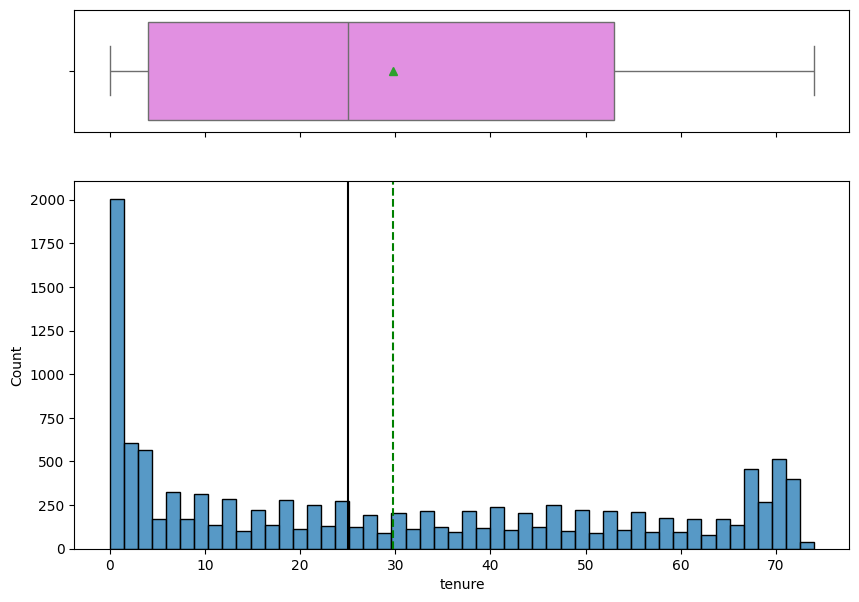

```python
histogram_boxplot(df,'tenure',bins=50)
```

- The histogram displays a bimodal distribution, which clearly shows two major concentrations of the datapoints: one very high peak at the beginning of the graph and the second, lower peak towards the end of the scale.
- There are a very large number of individuals who have extremely short tenure(0-5 months). On the other end a smaller, but significant group has a very long tenure(around 70 months).
- This pattern indicates a **retention crisis for new customers**, while those who stay past the initial phase are likely very loyal or satisfied.

# Observation on Monthly Charges

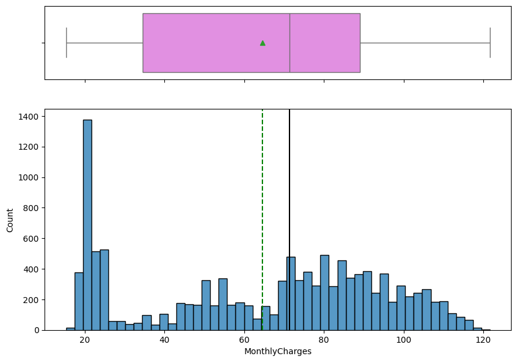

```python
histogram_boxplot(df,'MonthlyCharges', bins=50)
```

# Observation on Total Charges

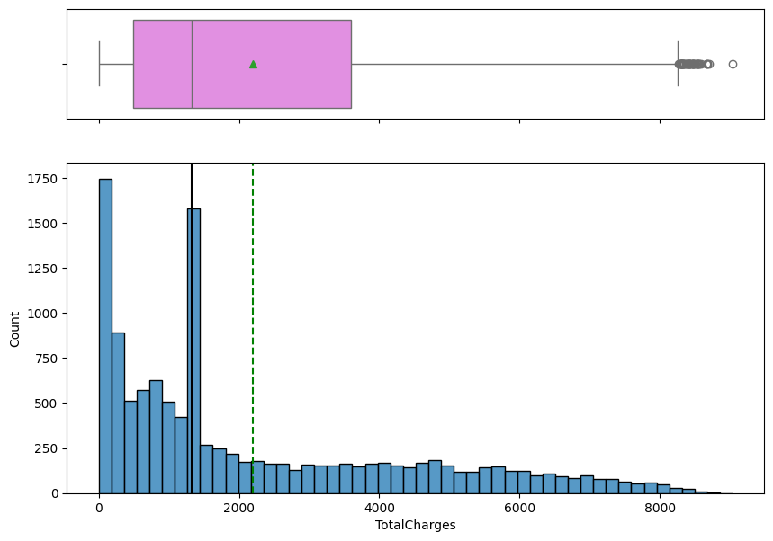

```python
histogram_boxplot(df,'TotalCharges', bins=50)
```

- The data is **right-skewed**, meaning most customers have lower total charges, with fewer customers having very high charges.
- A very large number of customers have total charges in the low ranges(around $0 to $2000). this suggests a significant portion of the customer base might consist of relatively new customers or those on lower-cost plans.
- there are some outliers in the right end of the boxplot, but they appear to be part of the natural skew of the data rather than extreme. We have to treat these outliers for further analysis.

# Observation on Gender

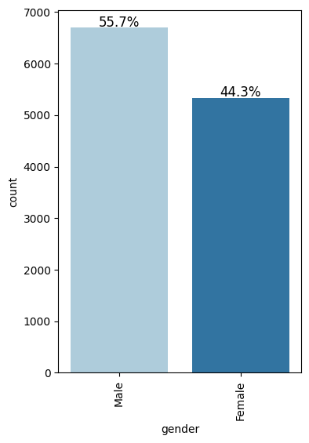

```python
labeled_barplot(df, "gender", perc=True);
```

- **Male** customers constitute **55.7%** of the total count, where **Female** customers constitute **44.3%** of the total count.

# Observation on Senior Citizen

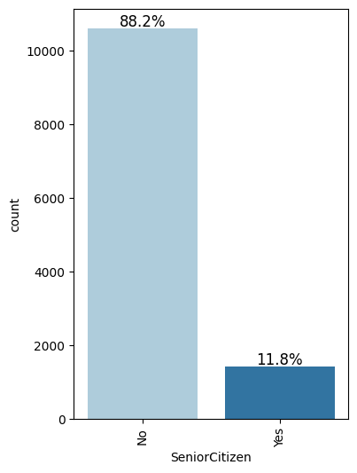

```python
labeled_barplot(df, "SeniorCitizen", perc=True);
```

- The majority of the customers(**88.2%**) are not in the Senior citizen category and remaining customers(**11.8%**) are classified as Senior citizens.

# Observation on Partner

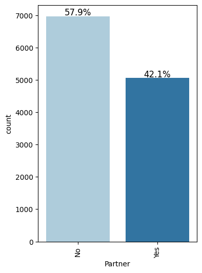

```python
labeled_barplot(df, "Partner", perc=True);
```

- The majority of the customers have no partner(**57.9%**) while the remaining customers have partner(**42.1%**).

# Observation on Dependents

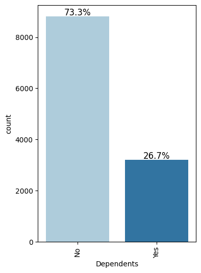

```python
labeled_barplot(df, "Dependents", perc=True);
```

- Maximum number of customers do not have dependents(**73.3%**) and remaining customers have dependents(**26.7%**).

# Observation on PhoneService

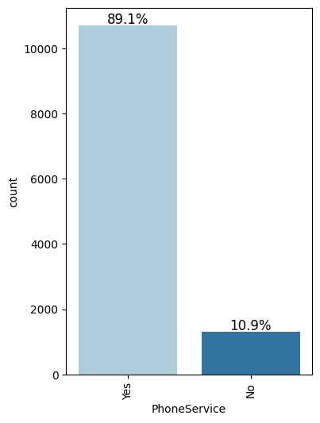

```python
labeled_barplot(df, "PhoneService", perc=True);
```

- A huge number of customers subscribed for Phone services(**89.1%**) while less number of customers have not subscribed for Phone services(**10.9%**).

# Observation on Multiple Lines

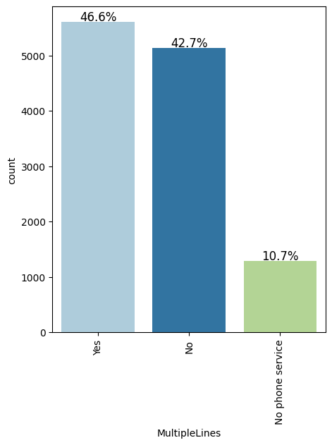

```python
labeled_barplot(df, "MultipleLines", perc=True);
```

- **46.6%** customers are using multiple phone lines and **42.7%** customers are using one phone line. And the reamining **10.7%** customers have no phone services.

# Observations on Internet Service

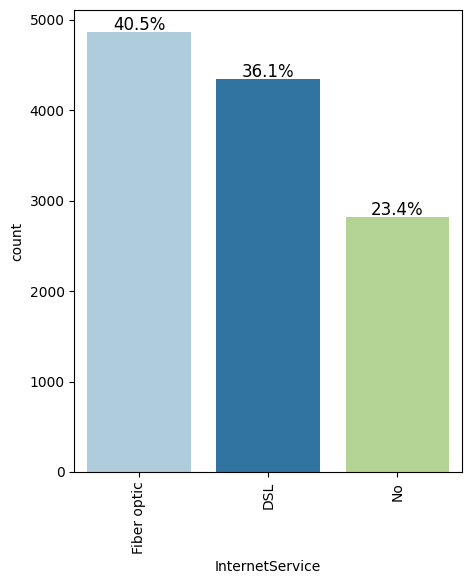

```python
labeled_barplot(df, "InternetService", perc=True);
```

- Most of the customers get internet services from Fibre optic(**40.5%**) followed by DSL(**36.1%**) and the remaining customers have no internet services(**23.4%**).

# Observation on Online Security

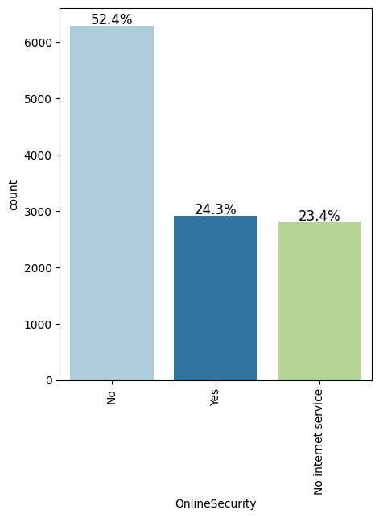

```python
labeled_barplot(df, "OnlineSecurity", perc=True);
```

# Observation on Online Backup

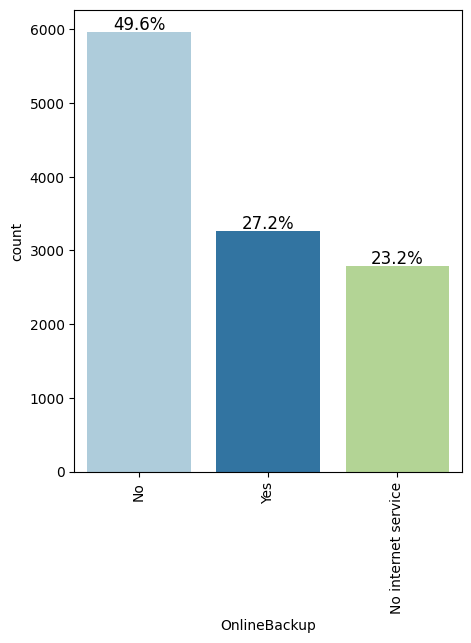

```python
labeled_barplot(df, "OnlineBackup", perc=True);
```

- A large number of customers have no online backup services(**49.6%**) and some of the customers have an online backup services(**27.2%**)and the remaining customers have no internet services to get online backup(**23.2%**).

# Observation on Device Protection

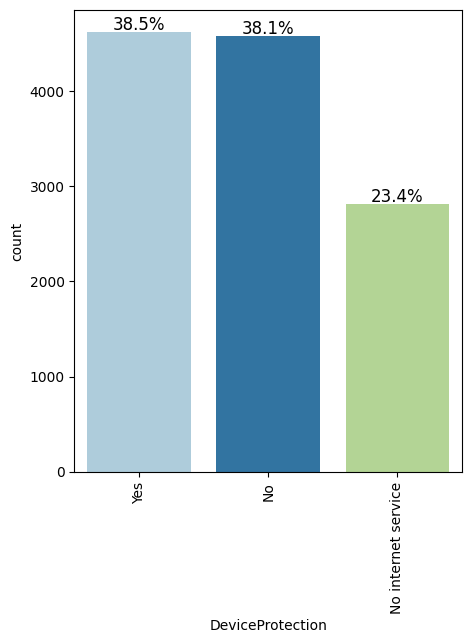

```python
labeled_barplot(df, "DeviceProtection", perc=True);
```

- The vast number of customers(approximately **76.6%**) falls into two categories, **Device Protection Service**: **Yes**(38.5%) and **No**(38.1%) which are nearly equal to each other.
- A significantly smaller segment belong to **No internet service**(23.4%).

# Observation on Tech Support

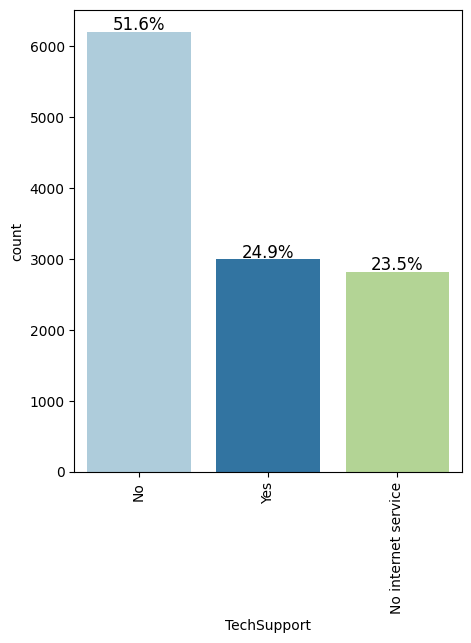

```python
labeled_barplot(df, "TechSupport", perc=True);
```

- Maximum number of customers did no subscribed(**51.6%**) for technical support services.

# Observation on Streaming TV

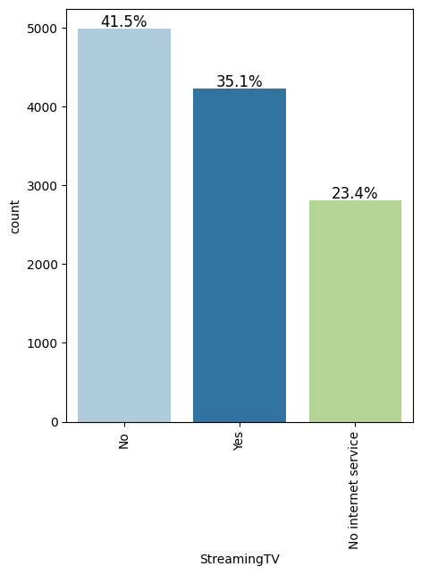

```python
labeled_barplot(df, "StreamingTV", perc=True);
```

- Most of the customers have not taken **Streaming TV** services(**41.5%**) but a good amount of customers subscribed(**35.1%**) for this service.

# Observation on Streaming Movies

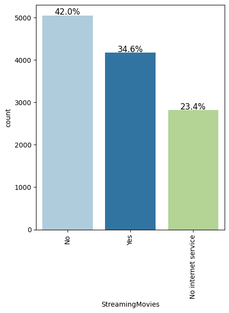

```python
labeled_barplot(df, "StreamingMovies", perc=True);
```

- Probably customers are same as they subscribed/not subscribed for **Streaming Movies** as well as Streaming TV.

# Observation on Contract

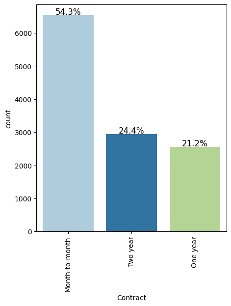

```python
labeled_barplot(df, "Contract", perc=True);
```

- maximum number of customers(**54.3%**) preferred **Month-to-month** contract. Some customers also go for yearly(one year, two year) contract but they are less in numbers.

# Observation on paperless Billing

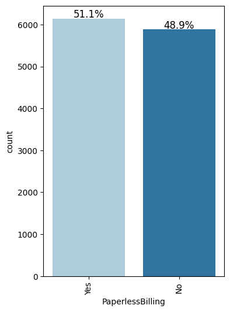

```python
labeled_barplot(df, "PaperlessBilling", perc=True);
```

- Majority of the customers use **Paperless Billing**(**51.1%**).

# Observation on Payment Method

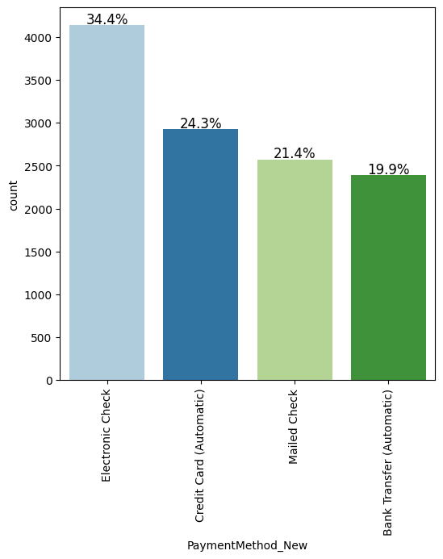

```python
labeled_barplot(df, "PaymentMethod_New", perc=True);
```

- **Electronic Check**(**34.4%**) payment method is the most frequently used by the customers. **Credit Card(Automatic)**(24.3%) And **Mailed Check**(21.4%) are good payment options for customers.
- Very less number of customers go for **Bank Transfer(Automatic)**(~20%) payment option.

# Observation on Churn

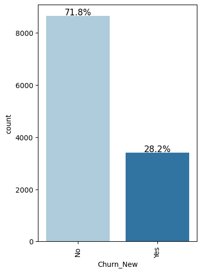

```python
labeled_barplot(df, "Churn_New", perc=True);
```

- Likely **28.2%** customers are churned and **71.8%** customers are not churned.

# **Bivariate Analysis**

**Observation on correlation Matrix on Numerical Variables**

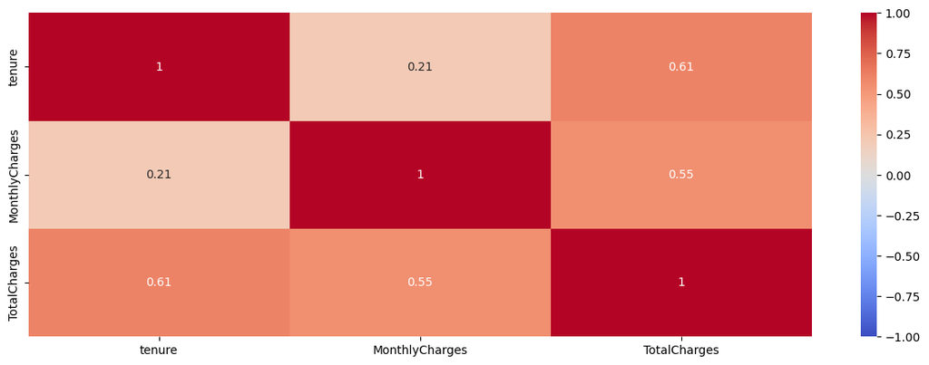

```python
plt.figure(figsize=(15,5))
sns.heatmap(df.corr(numeric_only=True),annot=True,cmap='coolwarm',vmin=-1,vmax=1)
plt.show()
```

- **Moderate positive** correlation between **Total charges** and **tenure**, indicating that as a customer's tenure increases, their total accumulated charges tend to increase significantly.
- **Moderate positive** correlation between **Total charges** and **Monthly charges**, meaning that customers with higher monthly bills also tend to have higher total charges, as expected.
- **Monthly charges** and **tenure** have no significant correlation between them.

**Observations on Customer Churn and Gender**

```
Churn_New    No   Yes    All
gender
All        8634  3394  12028
Male       4802  1893   6695
Female     3832  1501   5333
------------------------------------------------------------------------------------------------------------------------
```

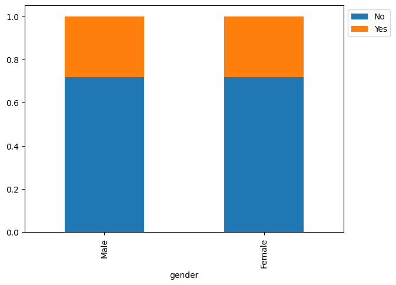

```python
stacked_barplot(df, "gender", "Churn_New")
```

**Observations on Customer Churn and Senior Citizen**

```
Churn_New        No   Yes    All
SeniorCitizen
All            8634  3394  12028
No             7816  2792  10608
Yes             818   602   1420
------------------------------------------------------------------------------------------------------------------------
```

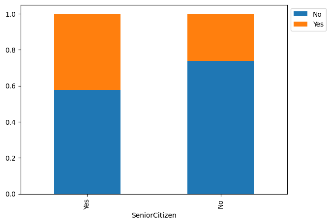

```python
stacked_barplot(df, "SeniorCitizen", "Churn_New")
```

**Observations on Customer Churn and Partner**

```
Churn_New    No   Yes    All
Partner
All        8634  3394  12028
No         4634  2336   6970
Yes        4000  1058   5058
------------------------------------------------------------------------------------------------------------------------
```

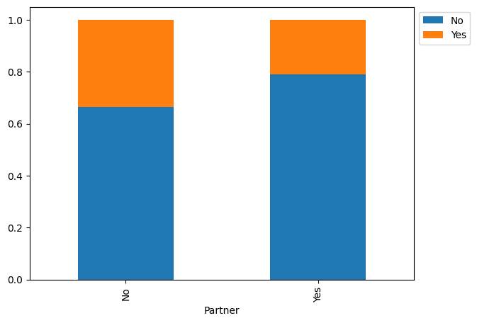

```python
stacked_barplot(df, "Partner", "Churn_New")
```

- Customers who **have a partner are less likely to churn** compared to unpartnered customers. Having a partner appears to be a protective factor against churn.

**Observations on Customer Churn and Dependents**

```
Churn_New     No   Yes    All
Dependents
All         8634  3394  12028
No          5944  2878   8822
Yes         2690   516   3206
------------------------------------------------------------------------------------------------------------------------
```

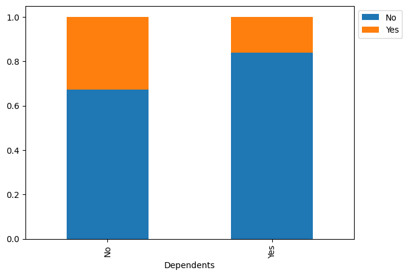

```python
stacked_barplot(df, "Dependents", "Churn_New")
```

- The Majority of the customers **do not have dependents are more likely to churn** compared to customers who do have dependents.

**Observations on Customer Churn and Phone Service**

```
Churn_New       No   Yes    All
PhoneService
All           8634  3394  12028
Yes           7655  3067  10722
No             979   327   1306
------------------------------------------------------------------------------------------------------------------------
```

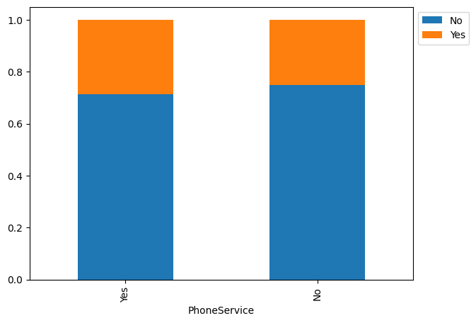

```python
stacked_barplot(df, "PhoneService", "Churn_New")
```

- It is clear that customers, who **have using Phone service are more likely to churn**(approximately **28.6%**) than the customers who do not have using Phone service(approximately 25%).

**Observations on Customer Churn and Multiple Lines**

```
Churn_New           No   Yes    All
MultipleLines
All               8634  3394  12028
Yes               3906  1698   5604
No                3759  1378   5137
No phone service   969   318   1287
------------------------------------------------------------------------------------------------------------------------
```

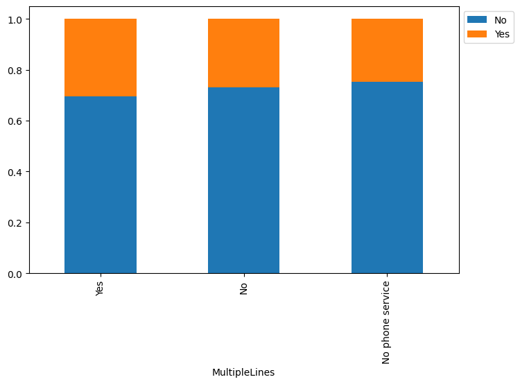

```python
stacked_barplot(df, "MultipleLines", "Churn_New")
```

- The customers who **have using multiple lines are more likely to churn**(approximately **30%**) compared to customers who do not have using multiple lines(approximately **26.9%**) and the customers who do not have any phone service(approximately **24.7%**).

**Observations on Customer Churn and Internet Service**

```
Churn_New          No   Yes    All
InternetService
All              8634  3394  12028
Fiber optic      2682  2184   4866
DSL              3400   945   4345
No               2552   265   2817
------------------------------------------------------------------------------------------------------------------------
```

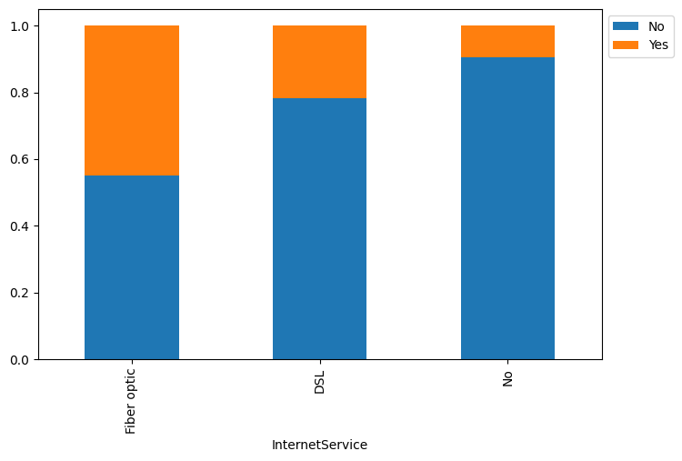

```python
stacked_barplot(df, "InternetService", "Churn_New")
```

**Observations on Customer Churn and Online Security**

```
Churn_New              No   Yes    All
OnlineSecurity
All                  8634  3394  12028
No                   3587  2712   6299
Yes                  2499   421   2920
No internet service  2548   261   2809
------------------------------------------------------------------------------------------------------------------------
```

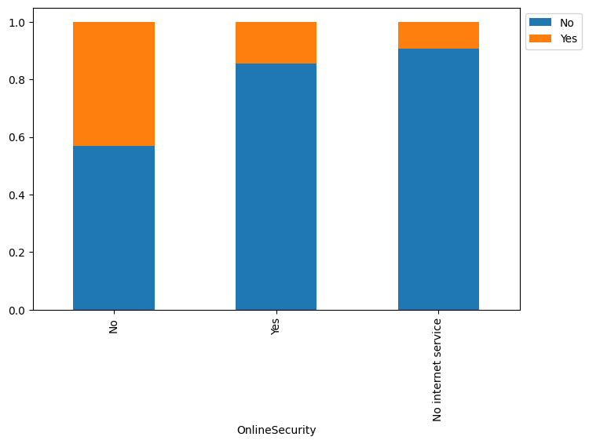

```python
stacked_barplot(df, "OnlineSecurity", "Churn_New")
```

- Customers who subscribe to **online security** are **less likely to leave** the service. And, the customers **without online security** services are substantially **more likely to churn**.